# Paz_Thal_MG_ClusteringGraphs_2022

## R Markdown

```r
#install.packages("BiocManager")
#BiocManager::install("Seurat")
#BiocManager::install("ggplot2")
#install.packages("dplr")
#install.packages("ape")
#install.packages("cowplot")
#install.packages("Matrix")
```

Load packages into your workspace.

```r
library(Seurat)
```

```r
library(ggplot2)
library(dplyr)
library(ape)
library(cowplot)
library(Matrix)

#find out where you are
getwd()
```

```
## [1] "/Users/whippoorwill/Desktop/Sequencing/Paz_Thalamus_2022/Paz_MG_TBI/Rmd"
```

*Edit the following code every time* and make sure the folders “QC” and “Plots” and “Heatmaps” and “Trees” and “Spreadsheets” and “Data/Seurat” are present in the “dir” folder

```r
#Specify your preferred directory for all input + output
dir= "/Users/whippoorwill/Desktop/Sequencing/Paz_Thalamus_2022/"

#Specify exactly where your seurat files live
datafolder = "Data/Seurat"

#set up folders
QCfolder = "QC"
Plotfolder = "Plots"

#This name needs to match your project name within the seurat object
project<-"Microglia_Paz_MG_Thal"


#the data file you want to open
filename = paste0(project,"_filtered.RData")

#Specify your organism; please capitalize the first letter (i.e. "Mouse", "Human","Zebrafish","Rat")
organism = "Mouse"

#metrics you want to look at for QC
m = c("nCount_RNA","nFeature_RNA","percent.mito","percent.ribo")

#You can add in housekeeping genes if you want them to be scaled always; otherwise set to "NULL"
add.genes = NULL

#Choose what to regress out - could be age, sex, or any metadata column
regress = c("percent.mito")

#Decide whether to use SCtransform (can take a long time with big datasets; generally recommended)
sct = TRUE

#How many genes do you want scaled to use for UMAP/clustering?
ngenes = 2000

#Which principal components do you want to calculate on? This is a default setting, change if one of the pc's is for something you think is a technical error (i.e. HSP, RP, etc)
pcs = c(1:30)

#clustering resolution; the last number will be saved as "seurat_clusters" in metadata
res = c(1.5,1.0,0.5)

#Important genes to determine your cells of interest
igenes = c("Slc1a3","Pecam1","Rbfox3","Pdgfra","Mbp","Cspg4","P2ry12","Hexb","Ptprc")

#metadata dimensions you want to cluster on
dims = c("seurat_clusters","sample_description","treatment","condition","fulldescription")

#edit to include all desired celltypes to subset on later; if not subsetting, set to "all"
keep = "microglia"

#make a unique name; maybe this is the celltype you've already subset, or the age you're looking at, etc.
iterationname = "mg1"

#Establish cutoffs for heatmaps
pval = 1e-8 #max p-value for significance
lfc = 0.2 #minimum log fold change
minpct = 0 #if you want to subset by percent cells in that cluster expressing the gene
maxpct = 1
single = F #should each gene be a marker of a single cluster only
hgenes = 3 #how many genes should be in the heatmap per cluster
ncells = 100 #max # of cells per heatmap column
column = "seurat_clusters" #division you care about

#Variance partition: Remove genes only associated with a technical variable or sex of the mouse
variance = F
```

Load in your filtered dataset

```r
load(file.path(dir,datafolder,filename))
```

Number of cells per sample:

```r
table(sobject$fulldescription)
```

```
##
## Control-IgG_Female   Control-IgG_Male    TBI-aCD4_Female      TBI-aCD4_Male
##               2257               1614               1464               1685
##     TBI-IgG_Female       TBI-IgG_Male
##               2823               2624
```

Plot important objects; check parameters before moving forward, evaluate QC, clustering

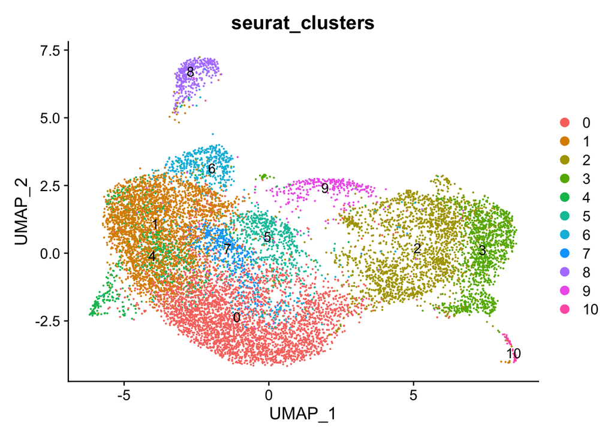

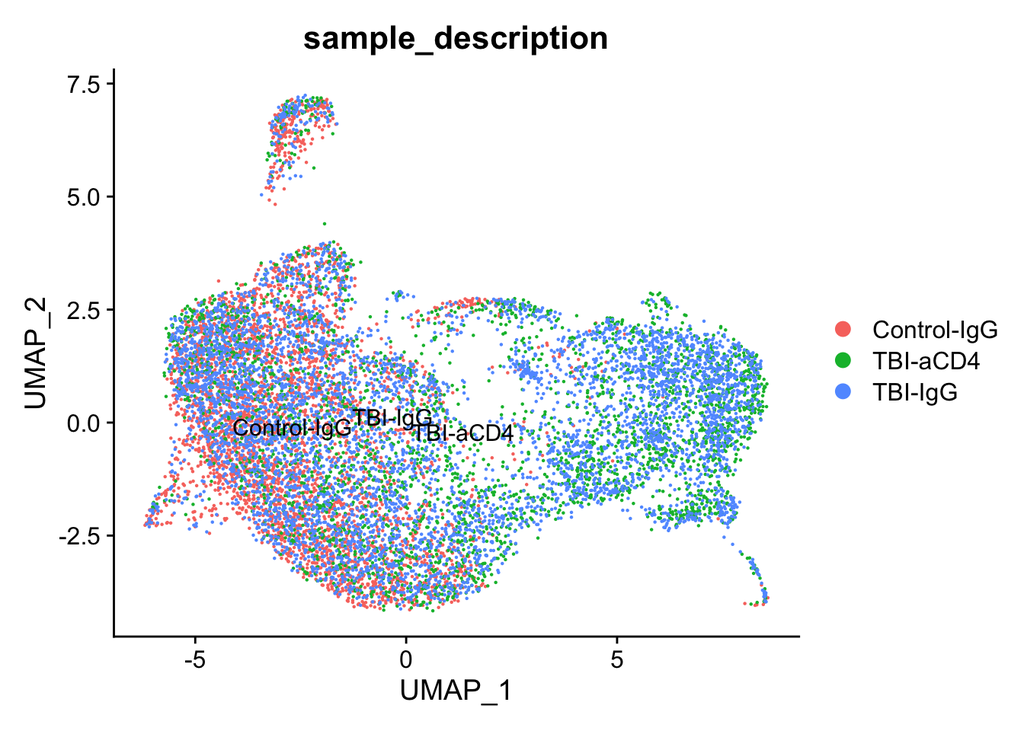

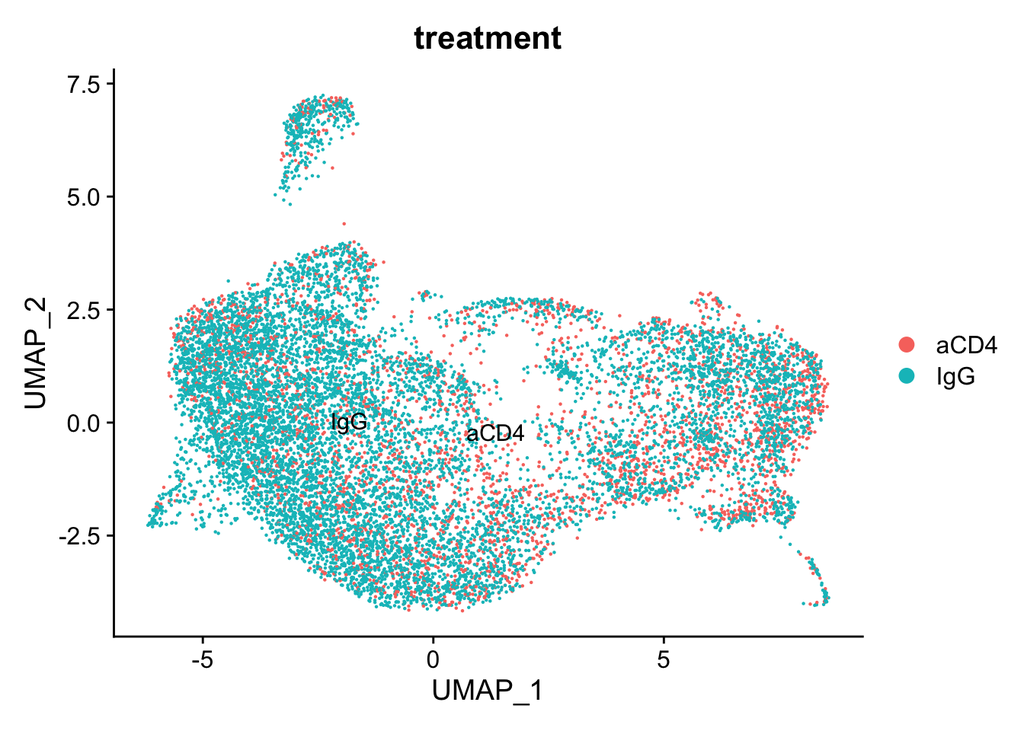

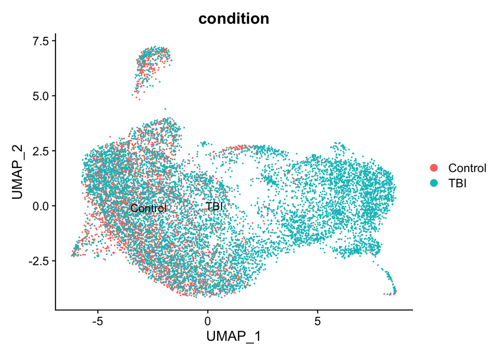

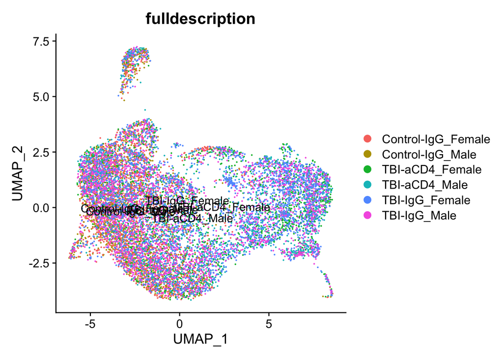

```r
for (dim in dims){
  print(DimPlot(sobject,group.by = dim, label = T))
}
```

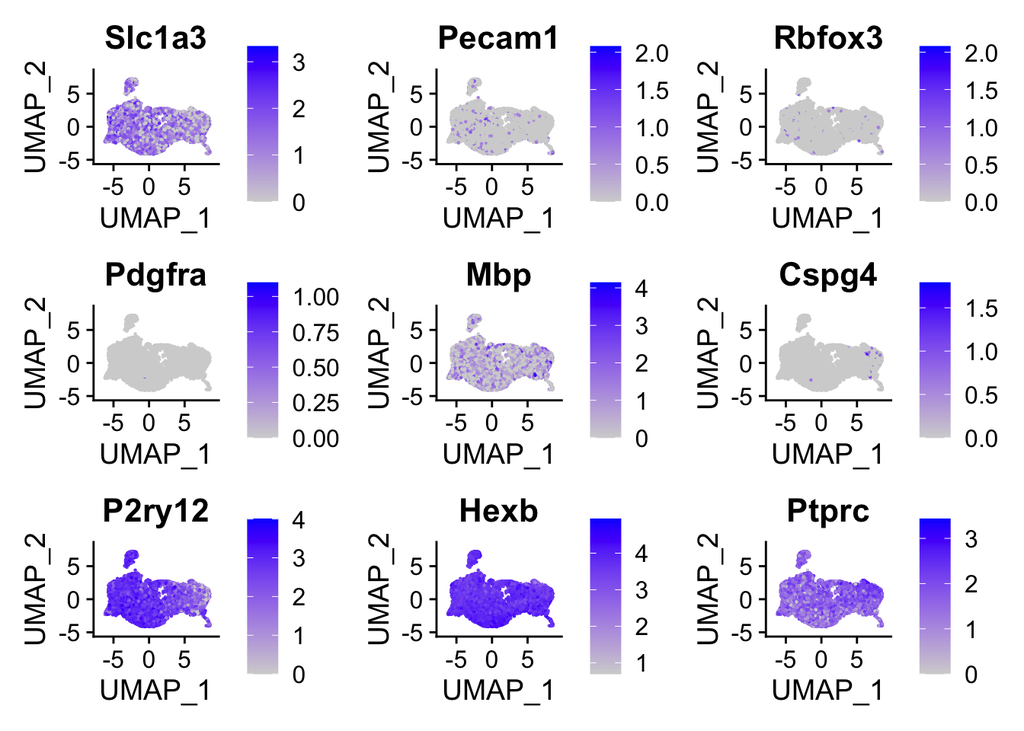

```r
FeaturePlot(sobject,igenes)
```

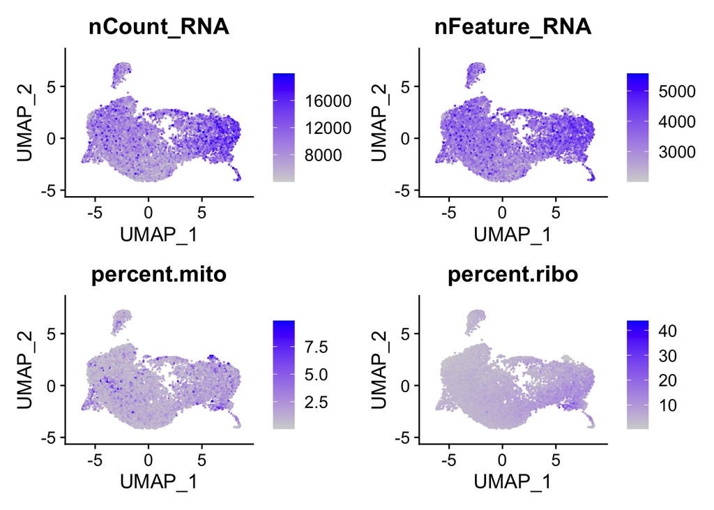

```r
FeaturePlot(sobject,m)
```

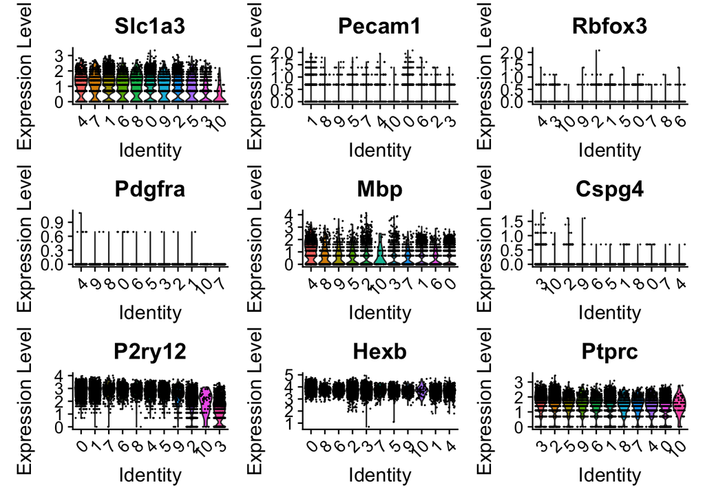

```r
VlnPlot(sobject,igenes,sort = "increasing",pt.size = 0.01)
```

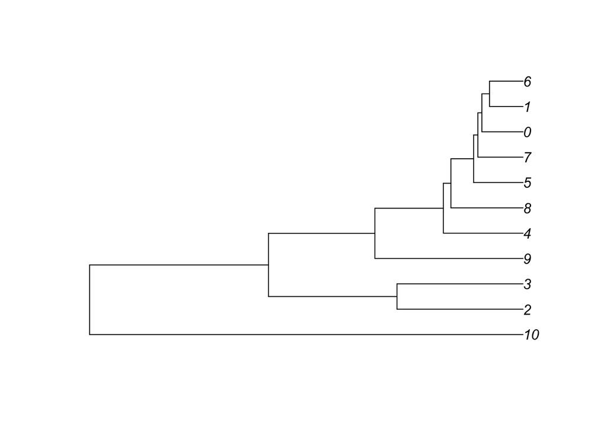

```r
#Build a clustering tree
Idents(sobject) = "seurat_clusters"
sobject= BuildClusterTree(sobject,dims = pcs)
tree = sobject@tools$BuildClusterTree
plot.phylo(tree, use.edge.length = T, direction = "rightwards")
```

```r
#read in a de gene file
markers = read.csv(file.path(dir,"Spreadsheets",paste0(iterationname,"_all_markers.csv")),stringsAsFactors = F)

#Select only the genes that pass thresholds
markers = markers[markers$p_val_adj<pval,]

#pick only positives, or restrict by min/max pct expression using pct1/2
markers = markers[markers$avg_log2FC > lfc,]
markers = markers[markers$pct.1 > minpct & markers$pct.2 < maxpct,]

#If you want, select markers that define a single cluster
if (single){markers <- markers[markers$gene %in% names(table(markers$gene))[table(markers$gene) == 1],] }

table(markers$cluster)
```

```
##
##   0   1   2   3   4   5   6   7   8   9  10
##   3 178 362 460  51  10   8   9   5  80 189
```

```r
topgenes <- markers %>% group_by(cluster) %>% top_n(hgenes, avg_log2FC)
topgenes = topgenes[order(topgenes$cluster),]

#Subset each cluster to ncells
cellnames = sobject@meta.data[,column]
names(cellnames) = colnames(sobject)
clusters = levels(as.factor(cellnames))
newcellnames = NULL
for (cluster in clusters){
  n = length(cellnames[cellnames == cluster])
  if (n > ncells){n = ncells}
  newcluster = sample(cellnames[cellnames == cluster],n, replace = F)
  newcellnames = c(newcellnames,newcluster)
}
```

Heatmap showing the top 3 differentially expressed genes by log fold change for each cluster.

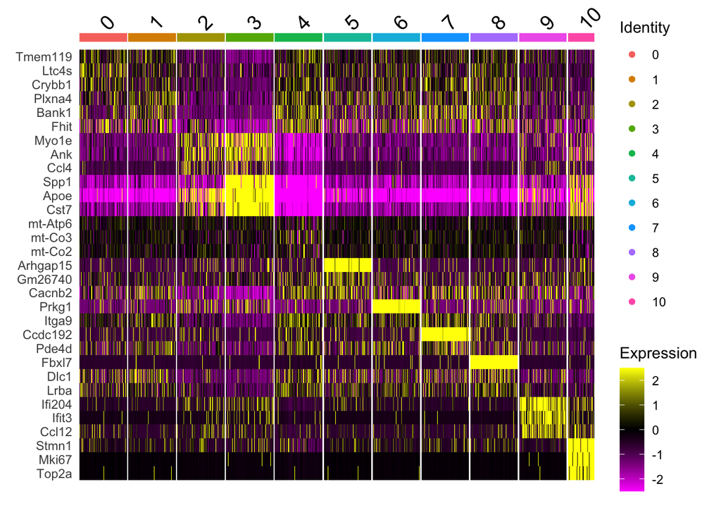

```r
DoHeatmap(
    object = sobject,
    features = c(topgenes$gene),
    cells = names(newcellnames),
    group.by = column,
    size = 5,
    label = T,
    draw.lines = T
)
```

Dotplot showing the top 3 differentially expressed genes by log fold change for each cluster.

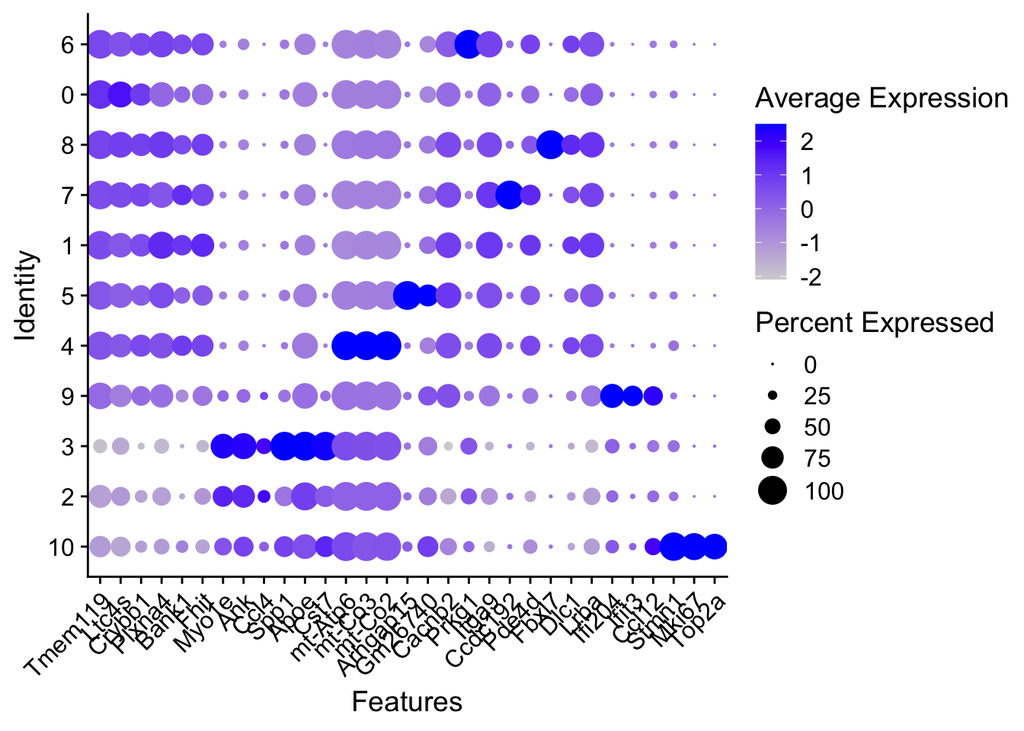

```r
genes = unique(topgenes$gene)
DotPlot(sobject,features = genes,group.by = "seurat_clusters",cluster.idents = T)+RotatedAxis()
```

Violin plots showing enrichment of the type-I interferon response I characterized (“IFN1”) and the DAM response shown by Keren-Shaul 2017 (“DAM1”) and neural genes (“neurogenes1”) to look for engulfment of neurons.

Split by cluster

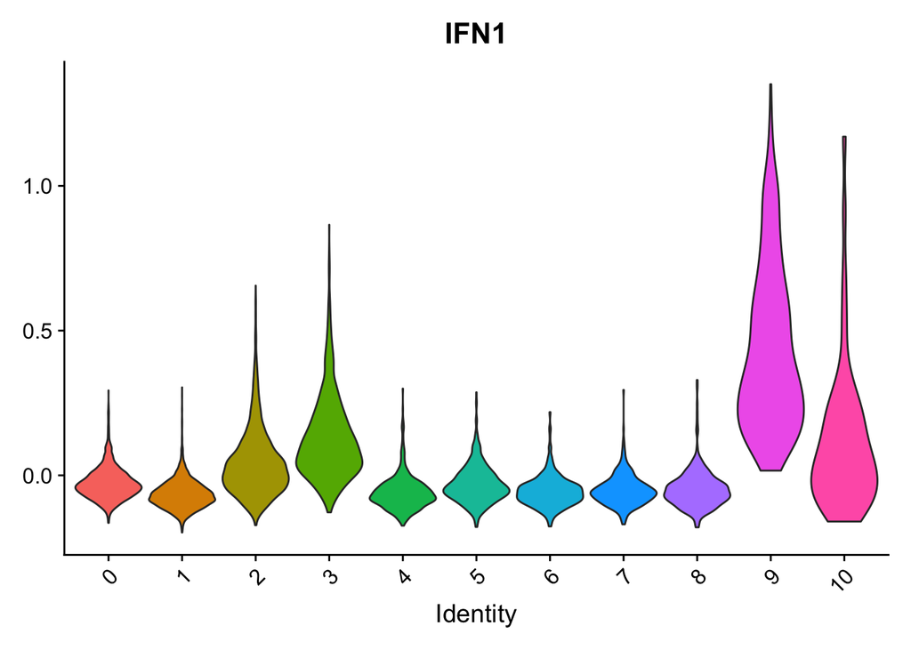

```r
VlnPlot(sobject,"IFN1",group.by = "seurat_clusters",pt.size = 0)+NoLegend()
```

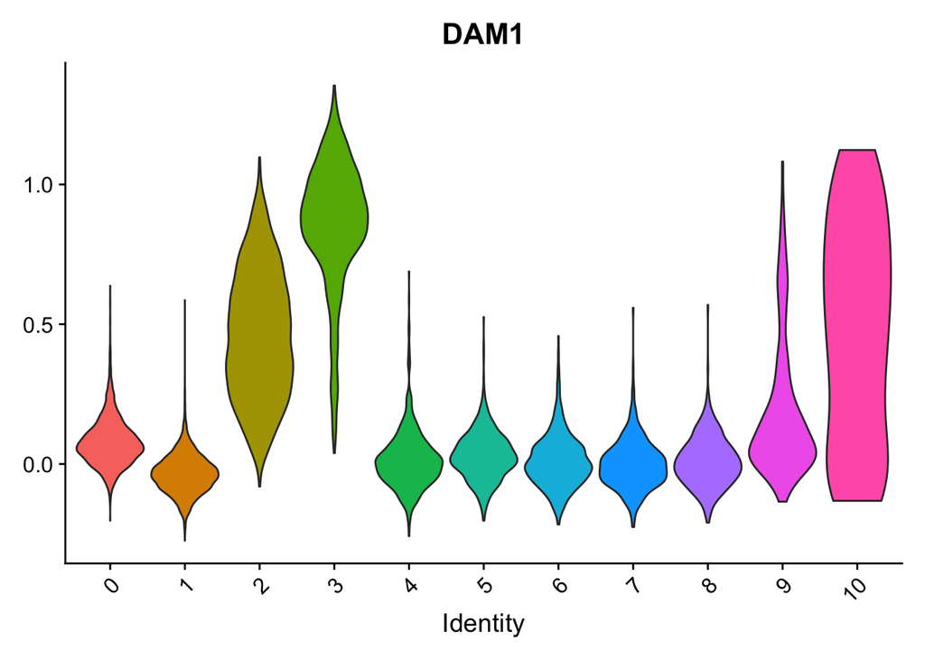

```r
VlnPlot(sobject,"DAM1",group.by = "seurat_clusters",pt.size = 0)+NoLegend()
```

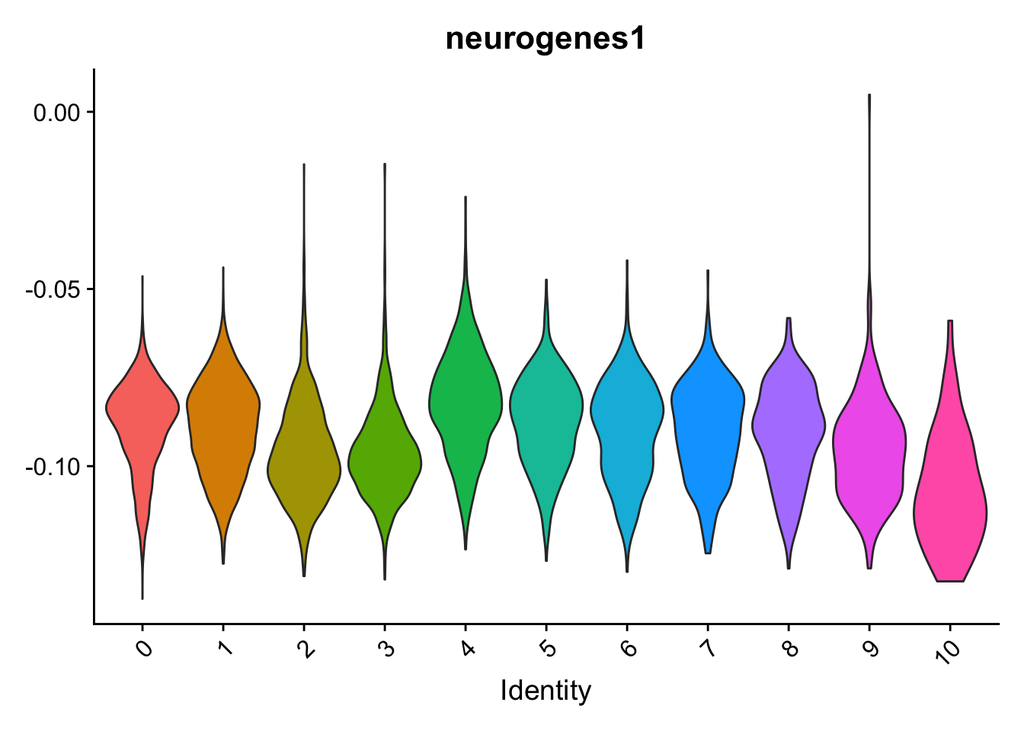

```r
VlnPlot(sobject,"neurogenes1",group.by = "seurat_clusters",pt.size = 0)+NoLegend()
```

Split by sample ID

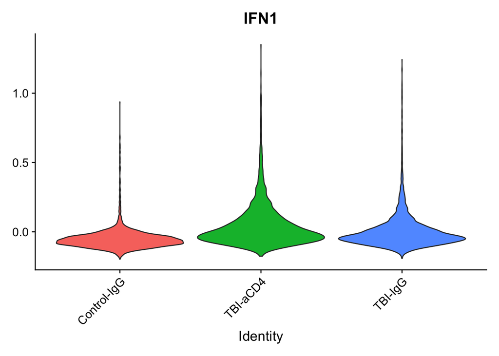

```r
VlnPlot(sobject,"IFN1",group.by = "sample_description",pt.size = 0)+NoLegend()
```

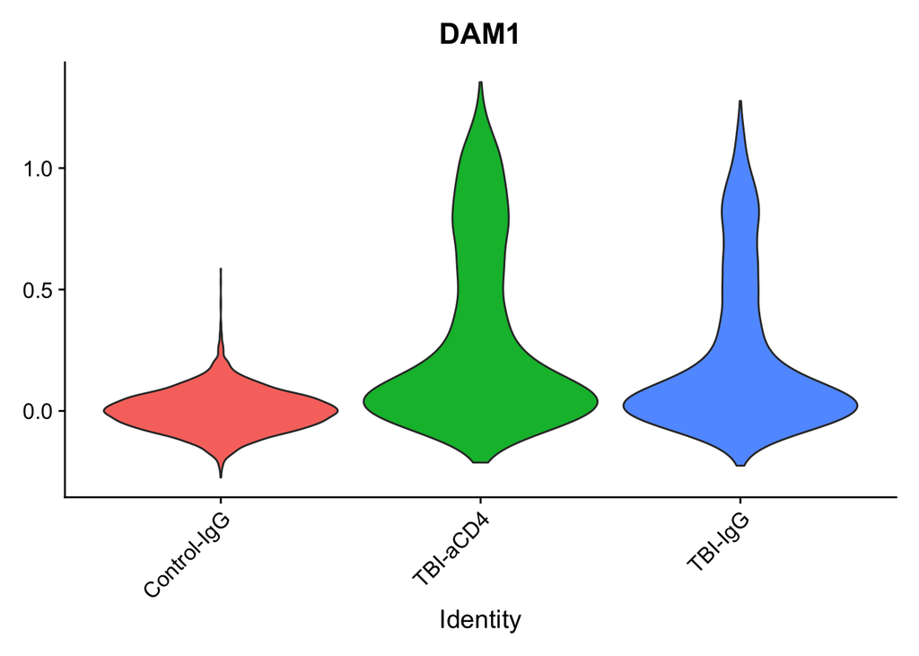

```r
VlnPlot(sobject,"DAM1",group.by = "sample_description",pt.size = 0)+NoLegend()
```

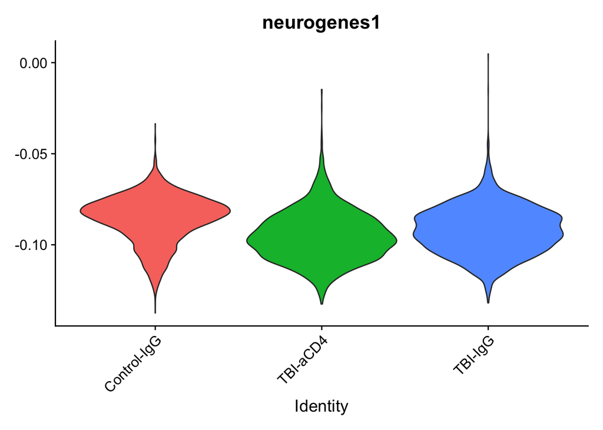

```r
VlnPlot(sobject,"neurogenes1",group.by = "sample_description",pt.size = 0)+NoLegend()
```

Barplot showing the relative makeup of each cluster by sample. The line is at 33%, and if there were no shift at all in cluster identity between conditions, every bar would be at 33%. Any bar above the line means that cluster is enriched in that sample.

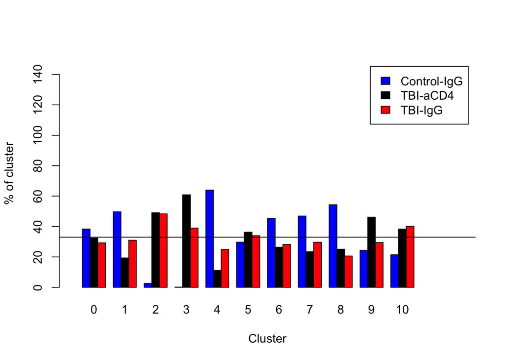

```
## numeric(0)
```

```r
t = table(sobject$seurat_clusters,sobject$sample_description)
b = apply(t,MARGIN = 2,function(x)x/sum(x)*100)
b = apply(b,MARGIN = 1,function(x)x/sum(x)*100)
barplot(b,beside = T,legend = rownames(b),col=c("blue","black","red"),ylim = c(0,150),xlim = c(0,50),xlab = "Cluster",ylab = "% of cluster") + abline(h=33)
```

Differential Gene Expression analysis and KEGG enrichment by cluster

```r
# install from CRAN
#install.packages("gprofiler2")
# load the package
library(gprofiler2)

#read in a de gene file
markers = read.csv(file.path(dir,"Spreadsheets",paste0(iterationname,"_all_markers.csv")),stringsAsFactors = F)

#Select only the genes that pass thresholds
markers = markers[markers$p_val_adj<pval,]

#pick only positives, or restrict by min/max pct expression using pct1/2
markers = markers[markers$avg_log2FC > lfc,]
markers = markers[markers$pct.1 > minpct & markers$pct.2 < maxpct,]

plotlist = list()
for (cluster in names(table(markers$cluster))){
  deg = markers[markers$cluster == cluster,]
  gp_up = gost(deg$gene, organism = "mmusculus",evcodes = T,sources = c("KEGG"), custom_bg = rownames(sobject))

  if (!is.null(gp_up)){
    plotlist[[cluster]] = gostplot(gp_up, interactive = TRUE)
  }
}
```

```
## Detected custom background input, domain scope is set to 'custom'
```

```
## No results to show
## Please make sure that the organism is correct or set significant = FALSE
```

```
## Detected custom background input, domain scope is set to 'custom'
## Detected custom background input, domain scope is set to 'custom'
## Detected custom background input, domain scope is set to 'custom'
## Detected custom background input, domain scope is set to 'custom'
## Detected custom background input, domain scope is set to 'custom'
```

```
## No results to show
## Please make sure that the organism is correct or set significant = FALSE
```

```
## Detected custom background input, domain scope is set to 'custom'
## Detected custom background input, domain scope is set to 'custom'
```

```
## No results to show
## Please make sure that the organism is correct or set significant = FALSE
```

```
## Detected custom background input, domain scope is set to 'custom'
```

```
## No results to show
## Please make sure that the organism is correct or set significant = FALSE
```

```
## Detected custom background input, domain scope is set to 'custom'
## Detected custom background input, domain scope is set to 'custom'
```

```r
names(plotlist)
```

```
## [1] "1"  "2"  "3"  "4"  "6"  "9"  "10"
```

```r
plotlist[['1']]
```

[interactive chart not shown]

```r
plotlist[['2']]
```

[interactive chart not shown]

```r
plotlist[['3']]
```

[interactive chart not shown]

```r
plotlist[['4']]
```

[interactive chart not shown]

```r
plotlist[['6']]
```

[interactive chart not shown]

```r
plotlist[['9']]
```

[interactive chart not shown]

```r
plotlist[['10']]
```

[interactive chart not shown]

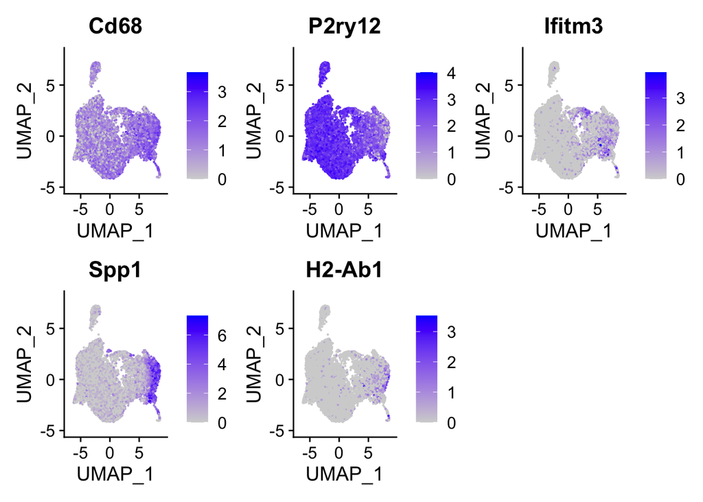

```r
FeaturePlot(sobject,c("Cd68","P2ry12","Ifitm3","Spp1","H2-Ab1"),ncol = 3)
```

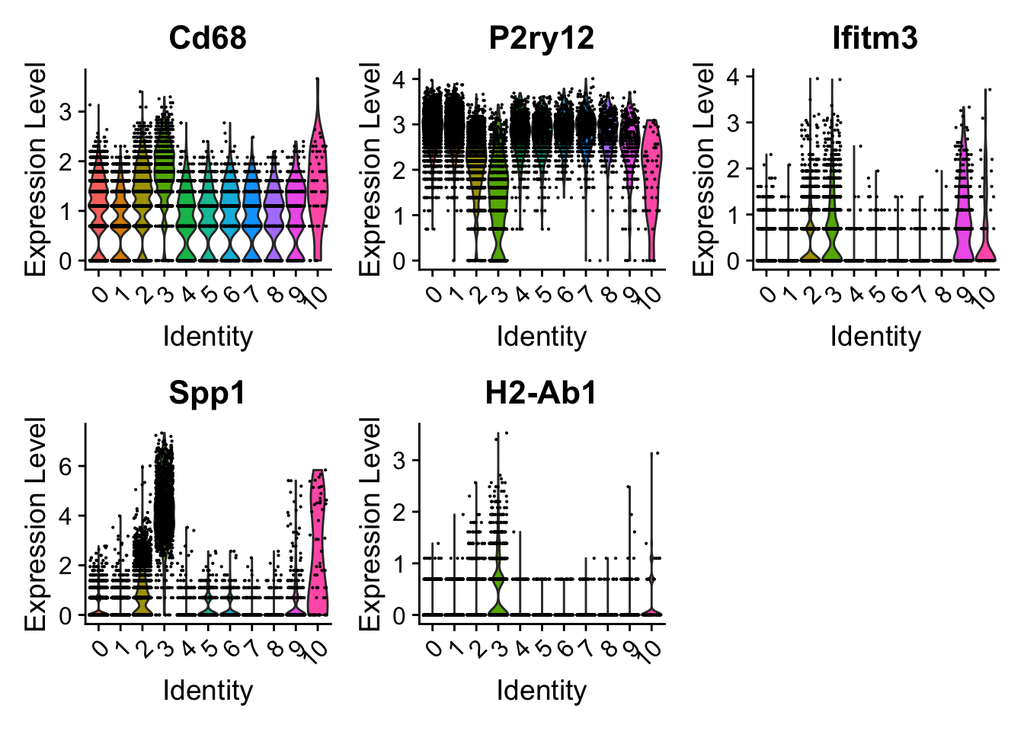

```r
VlnPlot(sobject,c("Cd68","P2ry12","Ifitm3","Spp1","H2-Ab1"),group.by = "seurat_clusters")
```

```r
allcells = sobject$sample_description
cellnames = c()
for (s in names(table(sobject$sample_description))){
  newcells = sample(allcells[allcells == s],3000)
  newcells = newcells
  cellnames = c(cellnames,newcells)
}
table(cellnames)
```

```
## cellnames
## Control-IgG    TBI-aCD4     TBI-IgG
##        3000        3000        3000
```

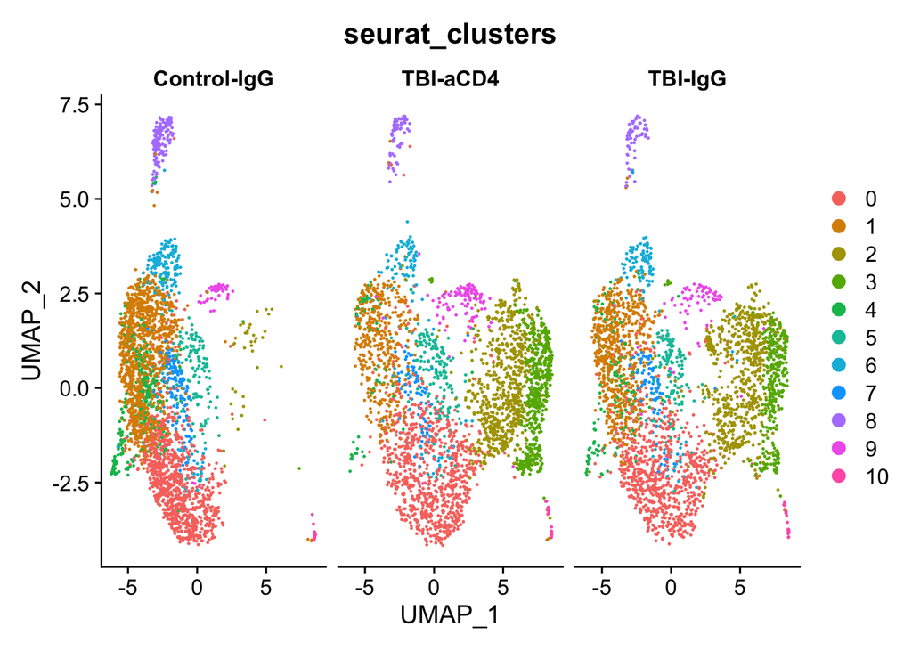

```r
newobject = subset(sobject,cells = names(cellnames))
DimPlot(newobject,group.by = "seurat_clusters",split.by = "sample_description")
```

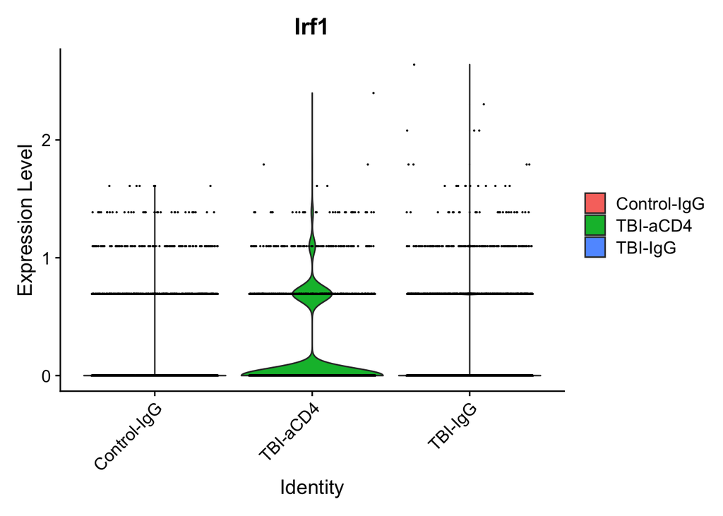

```r
VlnPlot(sobject,"Irf1",group.by = "sample_description")
```

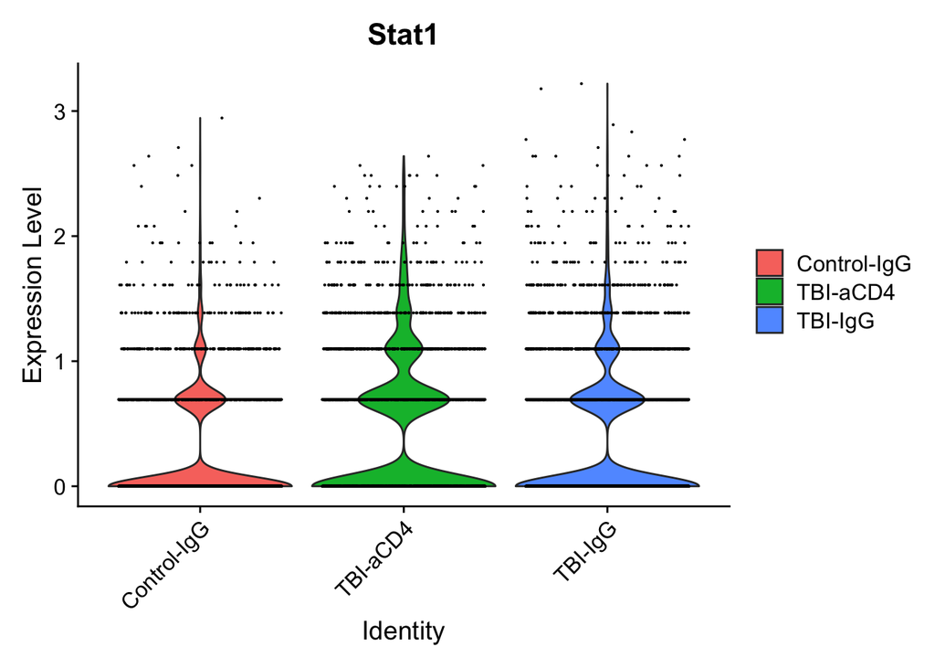

```r
VlnPlot(sobject,"Stat1",group.by = "sample_description")
```

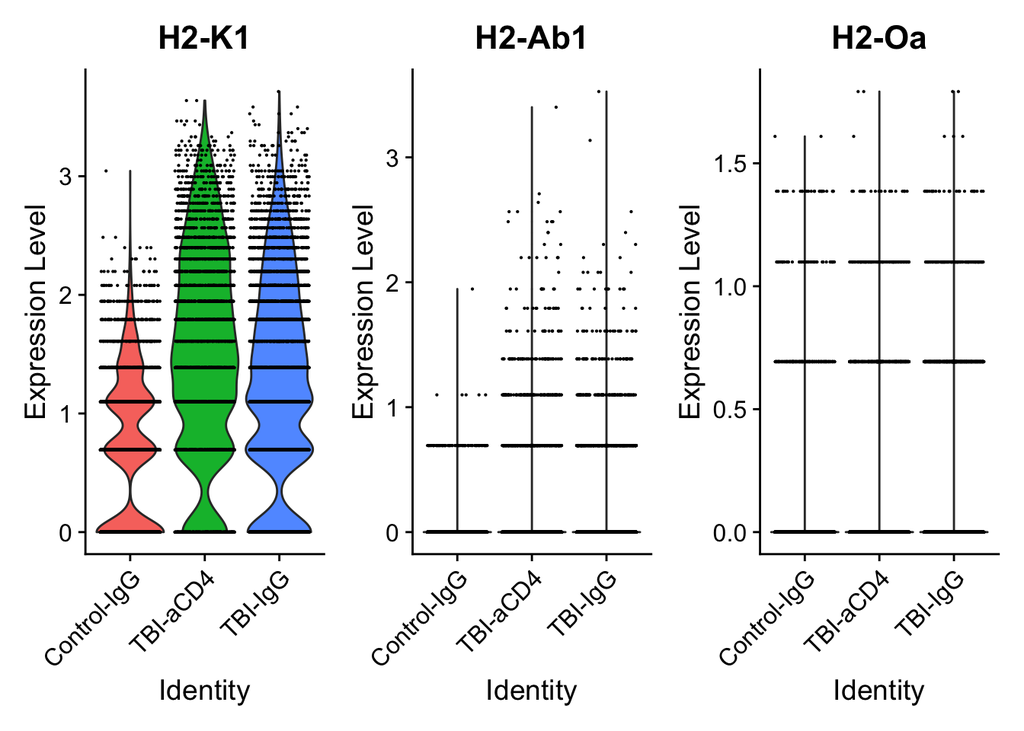

```r
VlnPlot(sobject,c("H2-K1","H2-Ab1","H2-Oa"),group.by = "sample_description")
```

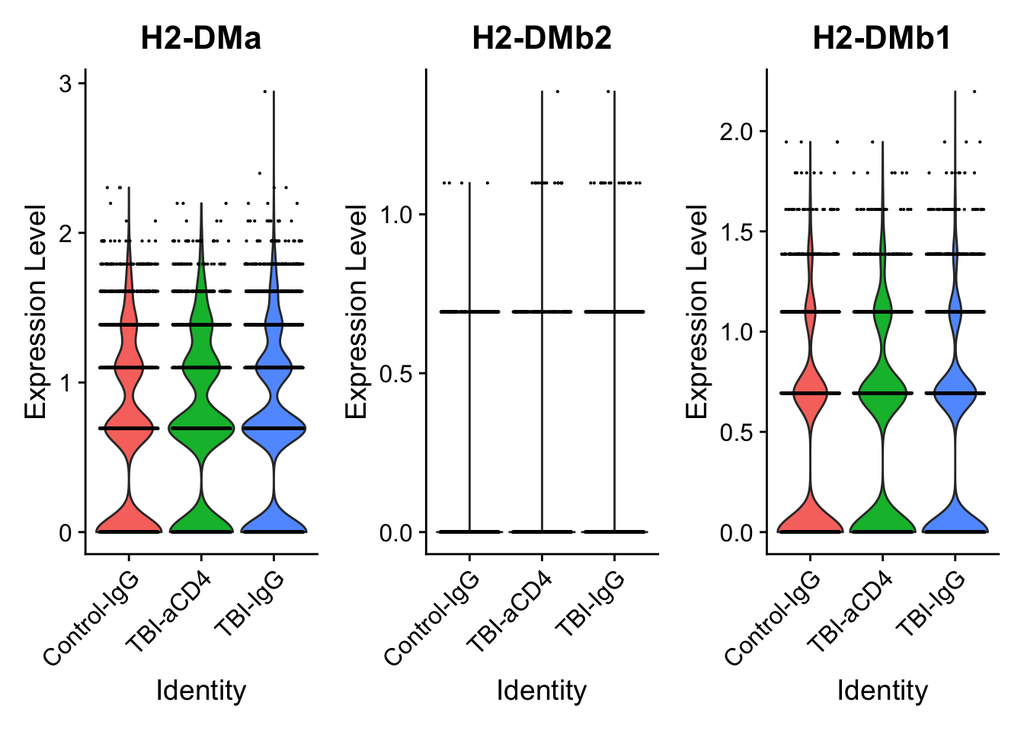

```r
VlnPlot(sobject,c("H2-DMa","H2-DMb2","H2-DMb1"),group.by = "sample_description")
```

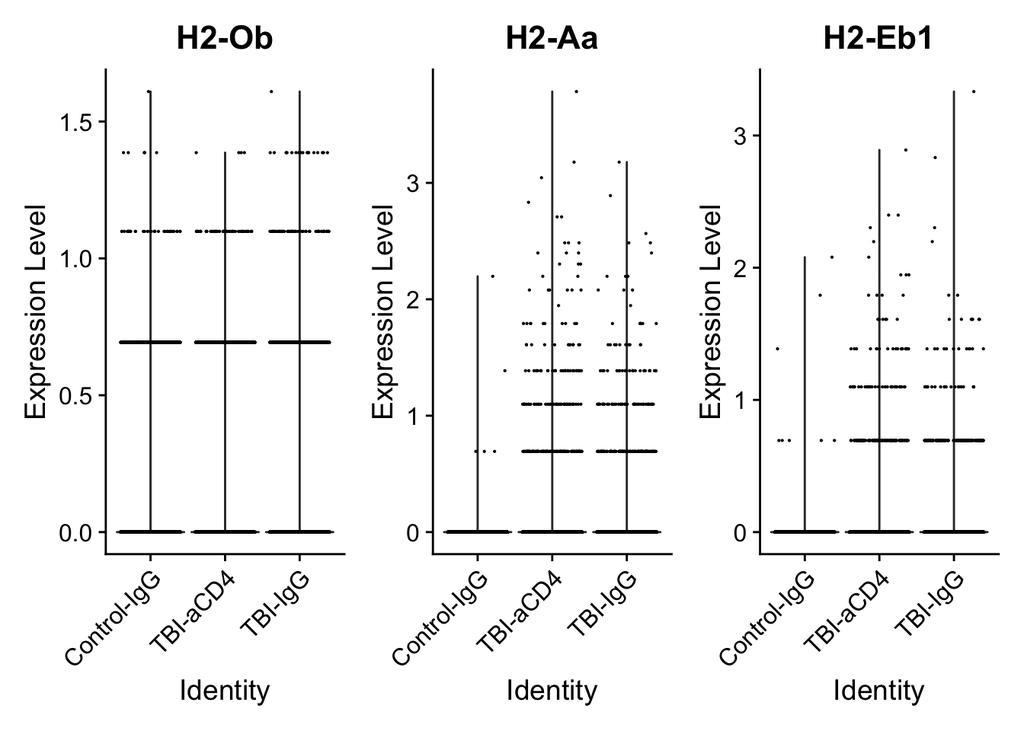

```r
VlnPlot(sobject,c("H2-Ob","H2-Aa","H2-Eb1"),group.by = "sample_description")
```

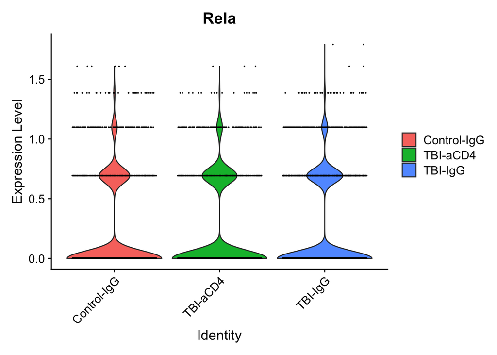

```r
VlnPlot(sobject,"Rela",group.by = "sample_description")
```

Analysis of genes differentially expressed between samples

```r
markers = read.csv(file = file.path(dir,"Spreadsheets","microglia_CD4vsIgG_TBI_markers.csv"))
markers = markers[markers$p_val_adj<pval,]
markers = markers[order(markers$avg_log2FC,decreasing = T),]
topgenes = markers$X[1:5]
topgenes = c(topgenes,markers$X[(nrow(markers)-5):nrow(markers)])
```

```r
markers = read.csv(file = file.path(dir,"Spreadsheets","microglia_TBIvsControl_markers.csv"))
markers = markers[markers$p_val_adj<pval,]
markers = markers[order(markers$avg_log2FC,decreasing = T),]
topgenes = c(markers$X[1:5],topgenes)
topgenes = c(topgenes,markers$X[(nrow(markers)-5):nrow(markers)])
```

Dotplot showing the most up- and down- regulated genes from these comparisons: 1) aCD4 vs IgG after TBI 2) TBI vs Sham

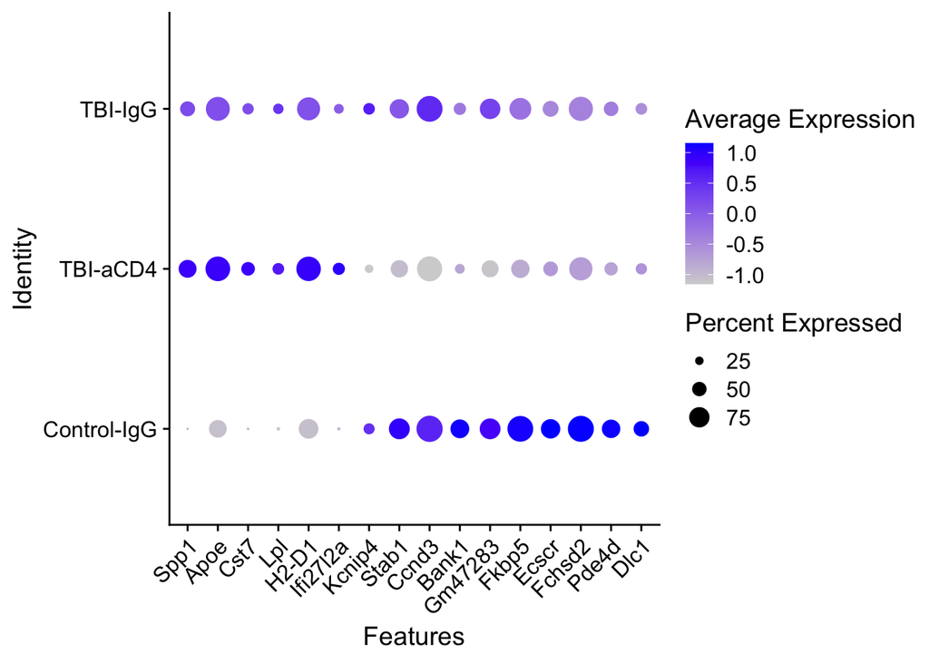

```r
DotPlot(sobject,features = unique(topgenes),group.by = "sample_description",cluster.idents = T)+RotatedAxis()
```

Heatmap showing the most up- and down- regulated genes from these comparisons. Each column is a cell, and 100 cells are shown per sample. 1) aCD4 vs IgG after TBI 2) TBI vs Sham

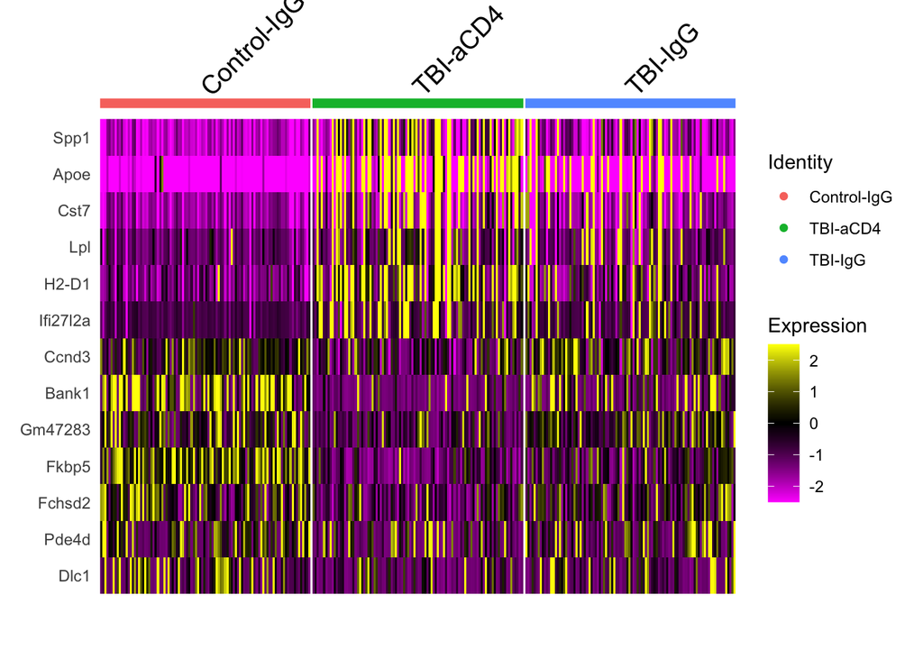

```r
allcells = sobject$sample_description
cellnames = c()
for (s in names(table(sobject$sample_description))){
  newcells = sample(allcells[allcells == s],100)
  newcells = newcells
  cellnames = c(cellnames,newcells)
}

DoHeatmap(
    object = sobject,
    features = topgenes,
    cells = names(cellnames),
    group.by = "sample_description",
    size = 5,
    label = T,
    draw.lines = T
)
```